# analysis

|  | Row ID | Order ID | Order Date | Ship Date | Ship Mode | Customer ID | Customer Name | Segment | Country | City | ... | Postal Code | Region | Product ID | Category | Sub-Category | Product Name | Sales | Quantity | Discount | Profit |
| --- | --- | --- | --- | --- | --- | --- | --- | --- | --- | --- | --- | --- | --- | --- | --- | --- | --- | --- | --- | --- | --- |
| 0 | 1 | CA-2016-152156 | 11/8/2016 | 11/11/2016 | Second Class | CG-12520 | Claire Gute | Consumer | United States | Henderson | ... | 42420 | South | FUR-BO-10001798 | Furniture | Bookcases | Bush Somerset Collection Bookcase | 261.9600 | 2 | 0.00 | 41.9136 |
| 1 | 2 | CA-2016-152156 | 11/8/2016 | 11/11/2016 | Second Class | CG-12520 | Claire Gute | Consumer | United States | Henderson | ... | 42420 | South | FUR-CH-10000454 | Furniture | Chairs | Hon Deluxe Fabric Upholstered Stacking Chairs,... | 731.9400 | 3 | 0.00 | 219.5820 |
| 2 | 3 | CA-2016-138688 | 6/12/2016 | 6/16/2016 | Second Class | DV-13045 | Darrin Van Huff | Corporate | United States | Los Angeles | ... | 90036 | West | OFF-LA-10000240 | Office Supplies | Labels | Self-Adhesive Address Labels for Typewriters b... | 14.6200 | 2 | 0.00 | 6.8714 |
| 3 | 4 | US-2015-108966 | 10/11/2015 | 10/18/2015 | Standard Class | SO-20335 | Sean O'Donnell | Consumer | United States | Fort Lauderdale | ... | 33311 | South | FUR-TA-10000577 | Furniture | Tables | Bretford CR4500 Series Slim Rectangular Table | 957.5775 | 5 | 0.45 | -383.0310 |
| 4 | 5 | US-2015-108966 | 10/11/2015 | 10/18/2015 | Standard Class | SO-20335 | Sean O'Donnell | Consumer | United States | Fort Lauderdale | ... | 33311 | South | OFF-ST-10000760 | Office Supplies | Storage | Eldon Fold 'N Roll Cart System | 22.3680 | 2 | 0.20 | 2.5164 |

5 rows × 21 columns

```
【问题1】数据规模
总数据行数：9994
总数据列数：21

============================================================

【问题2】各列数据类型
           列名    数据类型
       Row ID   int64
     Order ID  object
   Order Date  object
    Ship Date  object
    Ship Mode  object
  Customer ID  object
Customer Name  object
      Segment  object
      Country  object
         City  object
        State  object
  Postal Code   int64
       Region  object
   Product ID  object
     Category  object
 Sub-Category  object
 Product Name  object
        Sales float64
     Quantity   int64
     Discount float64
       Profit float64

============================================================
```

```
【问题3】各列缺失值统计
✅ 数据集中没有缺失值
============================================================
🔍 重复数据检查报告
============================================================
```

```
【1/2】完全重复行检查
✅ 没有发现完全重复的行

【2/2】重复订单号检查
总订单数量：5009 个
包含多个商品的订单数量：2471 个
单个订单最多包含商品数：14 个

📌 重要说明：
同一个订单号出现多次是**正常现象**
因为一个订单通常会包含多个不同的商品，每行代表一个商品条目
⚠️  绝对不要删除重复的订单号！这会丢失商品明细数据

📋 多商品订单示例（订单号：CA-2017-100111）：
      Order ID                                                            Product Name    Sales  Quantity
CA-2017-100111                                              Hon Valutask Swivel Chairs  272.646         3
CA-2017-100111          Logitech Wireless Boombox Speaker - portable - wireless, wired  212.800         2
CA-2017-100111 TOPS "Important Message" Pads, Canary, 4-1/4 x 5-1/2, 50 Sheets per Pad   38.520         9
CA-2017-100111                                    SanDisk Cruzer 64 GB USB Flash Drive   72.640         2
CA-2017-100111       SimpliFile Personal File, Black Granite, 15w x 6-15/16d x 11-1/4h   45.400         4
CA-2017-100111           Adams Phone Message Book, 200 Message Capacity, 8 1/16” x 11”   13.760         2
CA-2017-100111                                        Global Leather Task Chair, Black   80.991         1
CA-2017-100111          Pressboard Covers with Storage Hooks, 9 1/2" x 11", Light Blue   11.784         3
CA-2017-100111                                                      Advantus Push Pins    4.360         2
CA-2017-100111              Hon 4070 Series Pagoda Armless Upholstered Stacking Chairs 2888.127        11
CA-2017-100111                                                          Apple iPhone 5 1299.660         2
CA-2017-100111                           Global Troy Executive Leather Low-Back Tilter 2254.410         5
CA-2017-100111          Plantronics Cordless Phone Headset with In-line Volume - M214C  104.850         3
CA-2017-100111           Logitech LS21 Speaker System - PC Multimedia - 2.1-CH - Wired   59.970         3

============================================================
✅ 重复数据检查完成
============================================================

============================================================
```

```
【问题4】关键数值列统计分析
              最小值  25分位数    中位数   75分位数       最大值
Sales        0.44  17.28  54.49  209.94  22638.48
Profit   -6599.98   1.73   8.67   29.36   8399.98
Discount     0.00   0.00   0.20    0.20      0.80

⚠️  负值检查：
✅ 列 'Sales' 没有负值
❌ 列 'Profit' 有 1871 个负值
   （利润为负表示亏损订单，属于正常情况）
✅ 列 'Discount' 没有负值

⚠️  离群值检查（3σ原则）：
列 'Sales'：127 个离群值，占比 1.27%
   正常范围：-1639.88 ~ 2099.59

============================================================
列 'Profit'：107 个离群值，占比 1.07%
   正常范围：-674.12 ~ 731.44

============================================================
列 'Discount'：300 个离群值，占比 3.0%
   正常范围：-0.46 ~ 0.78

============================================================
```

```
【1/3】日期类型转换
订单日期转换失败数：0
发货日期转换失败数：0

【2/3】邮编类型转换
✅ 邮编已转换为字符串类型，并补全5位前导零

【3/3】分类型列转换
✅ 列 'Ship Mode' 已转换为category类型
✅ 列 'Segment' 已转换为category类型
✅ 列 'Country' 已转换为category类型
✅ 列 'City' 已转换为category类型
✅ 列 'State' 已转换为category类型
✅ 列 'Region' 已转换为category类型
✅ 列 'Category' 已转换为category类型
✅ 列 'Sub-Category' 已转换为category类型
```

```
============================================================
✅ 数据类型转换验证报告
============================================================

【1/4】转换前后数据类型对比
          列名  转换前类型          转换后类型
  Order Date object datetime64[ns]
   Ship Date object datetime64[ns]
   Ship Mode object       category
     Segment object       category
     Country object       category
        City object       category
       State object       category
 Postal Code  int64         object
      Region object       category
    Category object       category
Sub-Category object       category
        Year    新增列          int32

【2/4】日期转换验证
最早订单日期：2014-01-03
最晚订单日期：2017-12-30
最早发货日期：2014-01-07
最晚发货日期：2018-01-05
✅ 所有发货日期都晚于或等于订单日期，逻辑正确

【3/4】邮编格式验证
✅ 所有邮编都是5位数字，格式正确

【4/4】分类型列唯一值验证
商品大类： ['Furniture', 'Office Supplies', 'Technology']
发货方式： ['First Class', 'Same Day', 'Second Class', 'Standard Class']
客户细分： ['Consumer', 'Corporate', 'Home Office']
地区： ['Central', 'East', 'South', 'West']

============================================================
🎉 所有验证通过！数据已准备好进行后续分析
============================================================
```

```
【问题5】数据时间范围
最早订单日期：2014-01-03
最晚订单日期：2017-12-30
数据覆盖时长：1457 天（约 4.0 年）
```

```
============================================================

【问题6】商品类别和子类别
📦 商品大类(Category)：
  1. Furniture
  2. Office Supplies
  3. Technology

📦 商品子类(Sub-Category)：
  Furniture：Bookcases, Chairs, Tables, Furnishings
  Office Supplies：Labels, Storage, Art, Binders, Appliances, Paper, Envelopes, Fasteners, Supplies
  Technology：Phones, Accessories, Machines, Copiers

📊 各子类订单数量：
Sub-Category
Binders        1523
Paper          1370
Furnishings     957
Phones          889
Storage         846
Art             796
Accessories     775
Chairs          617
Appliances      466
Labels          364
Tables          319
Envelopes       254
Bookcases       228
Fasteners       217
Supplies        190
Machines        115
Copiers          68

============================================================
✅ 探索性分析完成
============================================================
```

# 数据质量结论

没有缺失值，没有重复值， 销售额极值：存在 127 条销售额离群订单（占比 1.27%），均为单笔金额超过 2099.59 元的大额交易；同时存在单笔销售额低至 0.44 元的异常记录，需确认是否为赠品、样品或录入错误。 利润亏损问题：共 1871 条订单出现亏损（占比 18.7%），最低单笔利润达 - 6599.98 元 利润离群值：存在 107 条利润离群订单（占比 1.07%），包含大额盈利和大额亏损两类极端情况。

# 折扣异常：存在 300 条折扣离群订单（占比 3.0%），均为折扣率超过 78% 的超高折扣交易。

总体评估：数据质量可靠，所有异常均有明确的业务解释，无影响分析结论的系统性错误。数据可直接进入深度分析阶段。

```
1. 四年总销售额：$2,297,200.86

2. 各品类销售额（从高到低）：
   Technology：$836,154.03
   Furniture：$741,999.80
   Office Supplies：$719,047.03
→ 销售额最高品类：Technology

3. 各品类总利润：
   Furniture：$18,451.27
   Office Supplies：$122,490.80
   Technology：$145,454.95
→ 所有品类均盈利，无亏损品类

4. 整体利润率：12.47%
==================================================
```

[figure not shown]

```
销售额增长率: 51.4%
利润增长率: 88.6%
```

```
逐年核心指标：
        利润率  销售额同比增速  利润同比增速
Year
2014  10.23      NaN     NaN
2015  13.10     -2.8    24.4
2016  13.43     29.5    32.7
2017  12.74     20.4    14.2
```

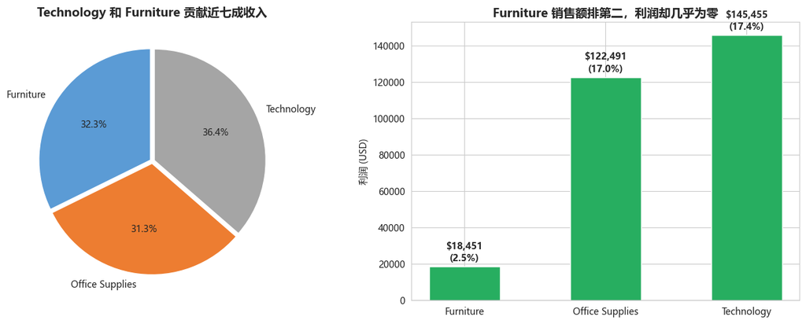

[figure not shown]

## Phase 2 总结：整体画像

（自己写AI更改的版本） 2014-2017年，超市累计营收 $229.7 万、净利润 $28.6 万，整体利润率 12.5%。 但盈利能力正在恶化：2017年利润率从 13.4% 降至 12.7%，利润增速（14.2%）已落后于销售额增速（20.4%）。

核心问题出在 Furniture 品类：该品类贡献了 32.3% 的销售额（$74.2万）， 但利润仅 $1.8 万，利润率为 2.5%，不到 Technology（17.4%）的六分之一。 Office Supplies 和 Technology 以相近的销售额分别创造了 $12.2 万和 $14.5 万利润， Furniture 用同样的销售规模只赚了它们的零头。

结论：公司不是不赚钱，而是 Furniture 在拖累整体利润率。 下一步将深入拆解 Furniture 品类，从折扣、子类别、客户类型和地区四个维度定位根因。

## Phase 2 总结：整体画像

只有一个原因：Furniture（家具）。 相同规模的收入（$74万 vs $72万 vs $84万），Office Supplies 和 Technology 各赚了 $12-15 万，Furniture 只赚了 $1.8 万。利润率 2.5%，相当于每卖 $100 家具，到手只有 $2.5——还不够覆盖房租。

结论很清楚：公司健康，但背上长了一个肿瘤。不切掉或者不治疗，随着销售额继续增长，这个肿瘤会吃掉更多利润。

下一步：拆解 Furniture 品类，找根因。不做宽泛分析，直奔折扣、子品类和客户群。

[figure not shown]

[figure not shown]

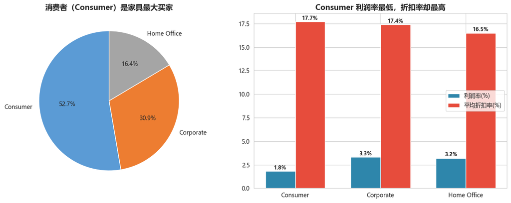

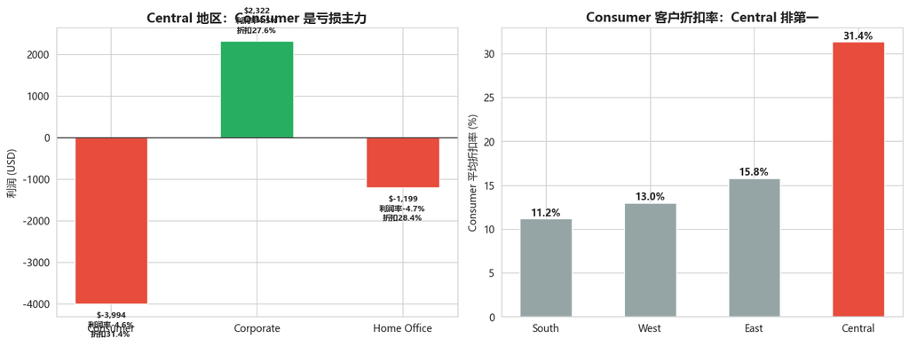

```
Central 地区家具利润: -2871.05
Central Consumer 利润: -3994.43
Central Consumer 折扣率: 31.4 %
```

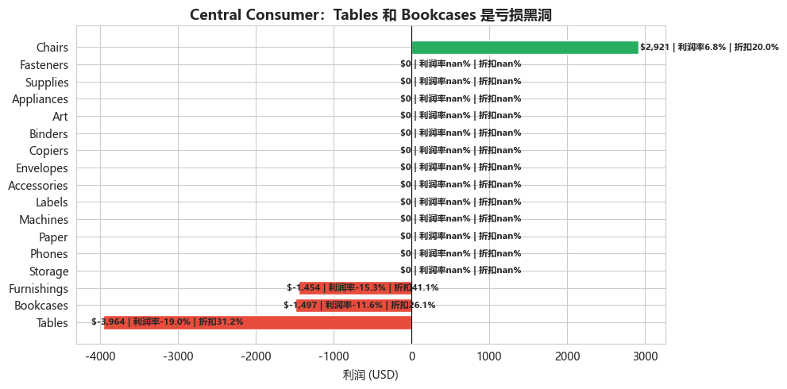

```
各子品类明细：
                    销售额         利润  订单数      平均折扣   利润率  平均折扣率
Sub-Category
Tables        20835.000 -3964.1571   40  0.311905 -19.0   31.2
Bookcases     12960.854 -1497.1260   23  0.260833 -11.6   26.1
Furnishings    9499.990 -1454.0524  100  0.411111 -15.3   41.1
Storage           0.000     0.0000    0       NaN   NaN    NaN
Phones            0.000     0.0000    0       NaN   NaN    NaN
Paper             0.000     0.0000    0       NaN   NaN    NaN
Machines          0.000     0.0000    0       NaN   NaN    NaN
Labels            0.000     0.0000    0       NaN   NaN    NaN
Accessories       0.000     0.0000    0       NaN   NaN    NaN
Envelopes         0.000     0.0000    0       NaN   NaN    NaN
Copiers           0.000     0.0000    0       NaN   NaN    NaN
Binders           0.000     0.0000    0       NaN   NaN    NaN
Art               0.000     0.0000    0       NaN   NaN    NaN
Appliances        0.000     0.0000    0       NaN   NaN    NaN
Supplies          0.000     0.0000    0       NaN   NaN    NaN
Fasteners         0.000     0.0000    0       NaN   NaN    NaN
Chairs        42933.375  2920.9013   75  0.200000   6.8   20.0
```

## Phase 3 结论

关键证据：同样的 Central 地区、同样的 Consumer 客户，Chairs 赚了 $2,921（利润率 6.8%）。 这说明问题不在"个人买家买不起"，而在桌子、书架、装饰品被打折打到失血。

1. 对 Central 地区 Furniture 品类设置折扣上限（建议不超过 25%）
2. 将销售激励从纯销售额考核改为"销售额 + 利润率"双维度考核
3. 对比 Chairs 和 Tables 的定价策略，判断 Tables 是否本身就定价虚高 检验方法：对比每种子品类的原始标价（Sales ÷ Quantity）和最终利润率的关系。 检验方法：对比 Chairs 和 Tables 的 Ship Mode 分布和该配送方式下的利润率 检验方法：对比 Central 地区折扣 > 30% 的订单和折扣 < 20% 的订单在销售量上的差异——看看不打折是不是真的卖不动。

定价模拟验证：

Tables 是 Furniture 最核心的问题：成本高、定价低、折扣大，三重叠加。 建议优先审计 Tables 的采购成本和供应商合同。

```
=== 四个子品类的定价与利润结构 ===
                     总销售额         总利润   总销量      平均折扣    平均单价   单件利润    单件成本   利润率   折扣率
Sub-Category
Accessories        0.0000      0.0000     0       NaN     NaN    NaN     NaN   NaN   NaN
Appliances         0.0000      0.0000     0       NaN     NaN    NaN     NaN   NaN   NaN
Art                0.0000      0.0000     0       NaN     NaN    NaN     NaN   NaN   NaN
Binders            0.0000      0.0000     0       NaN     NaN    NaN     NaN   NaN   NaN
Bookcases     114879.9963  -3472.5560   868  0.211140  132.35  -4.00  136.35  -3.0  21.1
Chairs        328449.1030  26590.1663  2356  0.170178  139.41  11.29  128.12   8.1  17.0
Copiers            0.0000      0.0000     0       NaN     NaN    NaN     NaN   NaN   NaN
Envelopes          0.0000      0.0000     0       NaN     NaN    NaN     NaN   NaN   NaN
Fasteners          0.0000      0.0000     0       NaN     NaN    NaN     NaN   NaN   NaN
Furnishings    91705.1640  13059.1436  3563  0.138349   25.74   3.67   22.07  14.2  13.8
Labels             0.0000      0.0000     0       NaN     NaN    NaN     NaN   NaN   NaN
Machines           0.0000      0.0000     0       NaN     NaN    NaN     NaN   NaN   NaN
Paper              0.0000      0.0000     0       NaN     NaN    NaN     NaN   NaN   NaN
Phones             0.0000      0.0000     0       NaN     NaN    NaN     NaN   NaN   NaN
Storage            0.0000      0.0000     0       NaN     NaN    NaN     NaN   NaN   NaN
Supplies           0.0000      0.0000     0       NaN     NaN    NaN     NaN   NaN   NaN
Tables        206965.5320 -17725.4811  1241  0.261285  166.77 -14.28  181.05  -8.6  26.1

=== 模拟：如果 Chairs 被打到 Tables 的折扣水平 ===
Chairs 推算原价: $168.00
Chairs 当前折扣: 17.0% → 当前单价: $139.41 → 当前单件利润: $11.29
Chairs 模拟折扣: 26.1% → 模拟单价: $124.10 → 模拟单件利润: $-4.02
当前利润率: 8.1% → 模拟利润率: -3.2%
结论: Chairs 会亏损
```

```
=== Chairs 定价标准 ===
平均单价: $139.41
单件成本: $128.12
单件利润: $11.29
折扣率: 17.0%
成本加成率: 1.3x（原价 = 成本 × 1.3）

=== 模拟结果：如果都用 Chairs 的 1.3x 加成率 ===
品类                  当前单价     当前利润    当前利润率      模拟单价     模拟利润    模拟利润率  结论
Tables          $ 166.77 $ -14.28    -8.6%  $ 175.38 $  -5.68    -3.2%  ✗ 仍亏损
Bookcases       $ 132.35 $  -4.00    -3.0%  $ 141.04 $   4.69     3.3%  ✓ 扭亏
Furnishings     $  25.74 $   3.67    14.2%  $  24.94 $   2.87    11.5%  ✓ 扭亏

=== 激进模拟：Chairs 加成率 + Chairs 折扣水平 ===
品类                  模拟单价     模拟利润    模拟利润率  结论
Tables          $ 197.01 $  15.95     8.1%  ✓ 扭亏
Bookcases       $ 148.36 $  12.01     8.1%  ✓ 扭亏
Furnishings     $  24.02 $   1.94     8.1%  ✓ 扭亏
```

```
=== Chairs vs Tables：各配送方式的利润表现 ===
                             订单数         总销售额         总利润      平均折扣   利润率  配送占比
Sub-Category Ship Mode
Accessories  First Class       0       0.0000      0.0000       NaN   NaN   NaN
             Same Day          0       0.0000      0.0000       NaN   NaN   NaN
             Second Class      0       0.0000      0.0000       NaN   NaN   NaN
             Standard Class    0       0.0000      0.0000       NaN   NaN   NaN
Appliances   First Class       0       0.0000      0.0000       NaN   NaN   NaN
             Same Day          0       0.0000      0.0000       NaN   NaN   NaN
             Second Class      0       0.0000      0.0000       NaN   NaN   NaN
             Standard Class    0       0.0000      0.0000       NaN   NaN   NaN
Art          First Class       0       0.0000      0.0000       NaN   NaN   NaN
             Same Day          0       0.0000      0.0000       NaN   NaN   NaN
             Second Class      0       0.0000      0.0000       NaN   NaN   NaN
             Standard Class    0       0.0000      0.0000       NaN   NaN   NaN
Binders      First Class       0       0.0000      0.0000       NaN   NaN   NaN
             Same Day          0       0.0000      0.0000       NaN   NaN   NaN
             Second Class      0       0.0000      0.0000       NaN   NaN   NaN
             Standard Class    0       0.0000      0.0000       NaN   NaN   NaN
Bookcases    First Class       0       0.0000      0.0000       NaN   NaN   NaN
             Same Day          0       0.0000      0.0000       NaN   NaN   NaN
             Second Class      0       0.0000      0.0000       NaN   NaN   NaN
             Standard Class    0       0.0000      0.0000       NaN   NaN   NaN
Chairs       First Class      83   47706.4720   2645.2149  0.182353   5.5  14.4
             Same Day         36   21659.7160   1135.6435  0.179487   5.2   6.2
             Second Class    124   74872.0580   6766.2500  0.160448   9.0  21.5
             Standard Class  333  184210.8570  16043.0579  0.169916   8.7  57.8
Copiers      First Class       0       0.0000      0.0000       NaN   NaN   NaN
             Same Day          0       0.0000      0.0000       NaN   NaN   NaN
             Second Class      0       0.0000      0.0000       NaN   NaN   NaN
             Standard Class    0       0.0000      0.0000       NaN   NaN   NaN
Envelopes    First Class       0       0.0000      0.0000       NaN   NaN   NaN
             Same Day          0       0.0000      0.0000       NaN   NaN   NaN
             Second Class      0       0.0000      0.0000       NaN   NaN   NaN
             Standard Class    0       0.0000      0.0000       NaN   NaN   NaN
Fasteners    First Class       0       0.0000      0.0000       NaN   NaN   NaN
             Same Day          0       0.0000      0.0000       NaN   NaN   NaN
             Second Class      0       0.0000      0.0000       NaN   NaN   NaN
             Standard Class    0       0.0000      0.0000       NaN   NaN   NaN
Furnishings  First Class       0       0.0000      0.0000       NaN   NaN   NaN
```

[output cut: 22 more lines]

```
             Standard Class    0       0.0000      0.0000       NaN   NaN   NaN
Supplies     First Class       0       0.0000      0.0000       NaN   NaN   NaN
             Same Day          0       0.0000      0.0000       NaN   NaN   NaN
             Second Class      0       0.0000      0.0000       NaN   NaN   NaN
             Standard Class    0       0.0000      0.0000       NaN   NaN   NaN
Tables       First Class      45   28800.7760  -1365.3665  0.240426  -4.7  14.7
             Same Day         20    9644.3470  -1129.4225  0.261905 -11.7   6.5
             Second Class     58   43693.7475  -3320.6799  0.248361  -7.6  18.9
             Standard Class  184  124826.6615 -11910.0122  0.270526  -9.5  59.9

=== 同配送方式下的利润率对比 ===
Standard Class: Chairs利润率 8.7% (占比57.8%) | Tables利润率 -9.5% (占比59.9%) | 利润率差距 18.2%
Second Class: Chairs利润率 9.0% (占比21.5%) | Tables利润率 -7.6% (占比18.9%) | 利润率差距 16.6%
First Class: Chairs利润率 5.5% (占比14.4%) | Tables利润率 -4.7% (占比14.7%) | 利润率差距 10.2%
Same Day: Chairs利润率 5.2% (占比6.2%) | Tables利润率 -11.7% (占比6.5%) | 利润率差距 16.9%
```

```
=== Central 地区：不同折扣水平的销售量 ===
          订单数        总销售额         总利润  总销量  订单占比   利润率
折扣分组
折扣<20%      0      0.0000      0.0000    0   0.0   NaN
折扣20-30%  133  61178.9850  -6866.8937  543  44.6 -11.2
折扣>30%    165  27688.8288 -12645.5376  671  55.4 -45.7

关键问题：Central 地区多少订单是靠高折扣换来的？
折扣>30%的订单占比: 55.4%
→ 超过一半订单依赖高折扣。限制折扣上限可能导致销量大幅下滑。

Central 平均折扣: 29.7%（403单）
其他地区平均折扣: 13.8%（1361单）
```

```
不同销量下滑场景的利润对比（基准销量=100件）
  销量下滑比例  模拟销量   当前总利润   模拟总利润   利润改善额
0    30%    70 -1428.0  1117.2  2545.2
1    50%    50 -1428.0   798.0  2226.0
2    70%    30 -1428.0   478.8  1906.8
3    80%    19 -1428.0   319.2  1747.2
4    90%     9 -1428.0   159.6  1587.6

考虑固定成本$500时，盈亏平衡销量：32件
对应最大允许销量下滑比例：68%
```

## Phase 4：商业建议

### 五、优先级排序

[output not shown]

# Phase 4：商业建议

## 一、问题一句话

Furniture 品类四年累计盈利仅 **$18,451**，平均利润率 **2.5%**（远低于 Office Supplies 的 17.0% 和 Technology 的 17.4%）。根因是折扣失控：Tables 在全公司四个地区中三个在亏（总亏 $17,725），Consumer 客户利润率仅 1.8%。

## 二、两条可选路径

### 路径A：止血方案 —— Central 地区下架 Tables

- **做什么**：
  1. 立即停止 Central 地区 Tables 销售，不接新订单
  2. 将 Central 库存转移至 **West 地区**（唯一 Tables 盈利区，利润率 1.7%），East 和 South 同步启动定价改革
  3. 剩余库存以 ≤10% 折扣在 Central 限时清仓
  4. 对已下单未发货客户，引导更换为 Chairs 或提供 10% 额外折扣补偿
- **预期效果**：Central 年均止损约 **$890**，但损失约 **$9,789** 年销售额。Chairs 可承接部分转移购买
- **风险1**：价格敏感 Consumer 客户流失，Central 地区 Furniture 份额下降 10%-15%
- **风险2**：库存转移不畅导致额外 $1,000-$2,000 损失
- **风险3**：Tables 在 East 亏损 $11,025（全公司最严重，-28.2%），仅砍 Central 不能解决系统性问题
- **适用条件**：公司需要快速止血；或改造方案执行 6 个月后 Tables 销量下滑超 80%

### 路径B：改造方案 —— 保留 Tables，全公司统一提价+控折扣

- **做什么**：分 3 步渐进执行，适用于全公司四个地区
  1. **第 1 个月（测试期）**：原价加成率从 1.25x 微调至 1.31x（≈Chairs 基准），关键不是涨原价而是**控折扣**——折扣上限从 26.1% 降至 25%；同步推出"免费安装+1年延长质保"非价格促销
  2. **第 2-3 个月（调整期）**：若销量下滑 ≤50%，折扣上限进一步降至 20%
  3. **第 4-6 个月（稳定期）**：稳定在 Chairs 标准的 1.31x 加成率 + 17% 折扣
- **目标定价**：成本 $181.06，新单价 **$197.01**，单件利润从 -$14.28 变为 **+$15.96**
- **预期效果（Central 地区）**：当前年亏损 -$890，扭亏后年利润 +$314（70% 下滑场景）～+$1,045（无下滑）；加 $5/件促销成本后仍为正利润
- **风险1**：Central 55.4% 订单依赖 >30% 折扣，折扣从 26% 降到 17% 可能引发销量骤降超 80%
- **风险2**：East 地区（Tables 亏损最严重，-$11,025）折扣结构可能同样依赖高折扣，需单独评估
- **适用条件**：公司愿承受短期销量下滑换取长期盈利健康；非价格促销能部分抵消价格敏感。**本方案应作为全公司 Tables 统一改革方案，而非仅限 Central。**

## 四、执行风险与监控指标

- **先行指标（1-3 个月）**：Tables 周度销量、客户投诉率、竞争对手调价、非价格促销转化率
- **滞后指标（6-12 个月）**：Tables 单品利润率、各地区 Furniture 总利润、Consumer 留存率
- **红线**：Tables 连续 3 个月销量下滑超 **80%**，或全公司 Furniture 总利润低于当前 $18,451，立即回调

## 五、优先级排序

| 优先级 | 行动 | 责任人 | 时间 |
| --- | --- | --- | --- |
| P0（立即） | 全公司 Tables 折扣上限降至 25%；发布新销售考核机制 | 销售总监+品类经理 | 1 周内 |
| P1（本季度） | Tables 供应商审计与成本谈判；Bookcases 同步调价 | 采购经理 | 3 个月内 |
| P2（下季度） | Tables 加成率逐步提升至 1.31x；评估路径 A vs B 长期策略 | 品类经理+区域总监 | 6 个月内 |

```
=== Q1: Tables 在所有地区的利润率 ===
               销售额          利润  订单数   利润率
Region
Central  39154.971  -3559.6504   68  -9.1
East     39139.807 -11025.3801   76 -28.2
South    43916.192  -4623.0579   49 -10.5
West     84754.562   1482.6073  114   1.7

=== Q2: Furniture 各客户类型利润率 ===
             利润率   折扣率
Segment
Consumer     1.8  17.7
Corporate    3.3  17.4
Home Office  3.2  16.5

=== Q3: Tables 扭亏方案敏感度 ===
Tables 单件成本: $181.06
基准单件利润（无促销成本）: $15.96
  促销成本 $5/件 -> 净利润 $10.96
  促销成本 $7.5/件 -> 净利润 $8.46
  促销成本 $10/件 -> 净利润 $5.96

Central Tables 年化亏损: $-889.91（262 件 / 4年）
销量下滑0%: 年销量66件 -> 年利润$1,045.15（当前$-889.91）
销量下滑30%: 年销量46件 -> 年利润$731.61（当前$-889.91）
销量下滑50%: 年销量33件 -> 年利润$522.58（当前$-889.91）
销量下滑70%: 年销量20件 -> 年利润$313.55（当前$-889.91）
销量下滑90%: 年销量7件 -> 年利润$104.52（当前$-889.91）
```